# ТИАБД_ПР3_Голомшыкин_ИКБО_08_21

Задание 1 Загрузить данные из файла “insurance.csv”.

```python
import pandas as pd
df = pd.read_csv(r'C:\Users\hanst\Downloads\insurance.csv')
df.head()
```

|  | age | sex | bmi | children | smoker | region | charges |
| --- | --- | --- | --- | --- | --- | --- | --- |
| 0 | 19 | female | 27.900 | 0 | yes | southwest | 16884.92400 |
| 1 | 18 | male | 33.770 | 1 | no | southeast | 1725.55230 |
| 2 | 28 | male | 33.000 | 3 | no | southeast | 4449.46200 |
| 3 | 33 | male | 22.705 | 0 | no | northwest | 21984.47061 |
| 4 | 32 | male | 28.880 | 0 | no | northwest | 3866.85520 |

Задание 2 С помощью метода describe() посмотреть статистику по данным. Сделать выводы.

```python
df.describe()
```

|  | age | bmi | children | charges |
| --- | --- | --- | --- | --- |
| count | 1338.000000 | 1338.000000 | 1338.000000 | 1338.000000 |
| mean | 39.207025 | 30.663397 | 1.094918 | 13270.422265 |
| std | 14.049960 | 6.098187 | 1.205493 | 12110.011237 |
| min | 18.000000 | 15.960000 | 0.000000 | 1121.873900 |
| 25% | 27.000000 | 26.296250 | 0.000000 | 4740.287150 |
| 50% | 39.000000 | 30.400000 | 1.000000 | 9382.033000 |
| 75% | 51.000000 | 34.693750 | 2.000000 | 16639.912515 |
| max | 64.000000 | 53.130000 | 5.000000 | 63770.428010 |

Задание 3 Построить гистограммы для числовых показателей. Сделать выводы.

```
array([[<Axes: title={'center': 'age'}>, <Axes: title={'center': 'bmi'}>],
       [<Axes: title={'center': 'children'}>,
        <Axes: title={'center': 'charges'}>]], dtype=object)
```

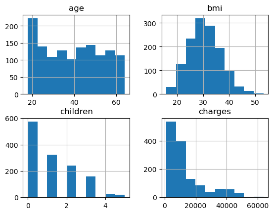

```python
df.hist()
```

Задание 4 Найти меры центральной тенденции и меры разброса для индекса массы тела (bmi) и расходов (charges). Отобразить результаты в виде текста и на гистограммах (3 вертикальные линии). Добавить легенду на графики. Сделать выводы.

```python
import scipy.stats as sts
import numpy as np

print('BMI мода', sts.mode(df['bmi'].to_numpy())[0])
print('BMI медиана', np.median(df['bmi'].to_numpy()))
print('BMI среднее', np.mean(df['bmi'].to_numpy()))
print('BMI размах', df['bmi'].to_numpy().max() - df['bmi'].to_numpy().min())
print('BMI стандартное отклонение', df['bmi'].to_numpy().std())
print('BMI межквартильный размах', sts.iqr(df['bmi'], interpolation = 'midpoint'))
print('Chrges мода', sts.mode(df['charges'].to_numpy())[0])
print('Chrges медиана', np.median(df['charges'].to_numpy()))
print('Chrges среднее', np.mean(df['charges'].to_numpy()))
print('Chrges размах', df['charges'].to_numpy().max() - df['charges'].to_numpy().min())
print('Chrges стандартное отклонение', df['charges'].to_numpy().std())
print('Chrges межквартильный размах', sts.iqr(df['charges'], interpolation = 'midpoint'))
```

```
BMI мода 32.3
BMI медиана 30.4
BMI среднее 30.66339686098655
BMI размах 37.17
BMI стандартное отклонение 6.0959076415894256
BMI межквартильный размах 8.384999999999998
Chrges мода 1639.5631
Chrges медиана 9382.033
Chrges среднее 13270.422265141257
Chrges размах 62648.554110000005
Chrges стандартное отклонение 12105.484975561612
Chrges межквартильный размах 11879.80148
```

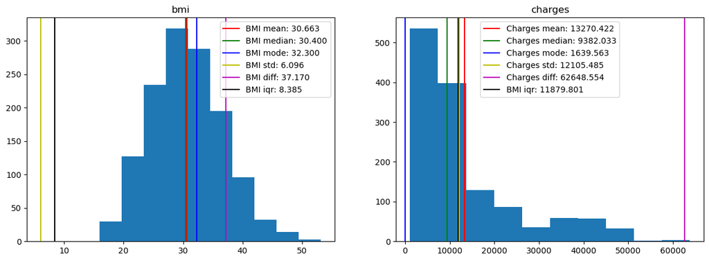

```python
import matplotlib.pyplot as plt

fig, ax = plt.subplots(1,2, figsize = (15, 5))

BMI_ax = ax[0]

BMI_ax.hist(df['bmi'])
BMI_ax.title.set_text('bmi')
Charges_mean = np.mean(df['bmi'].to_numpy())
BMI_ax.axvline(x = Charges_mean, color = 'r', linestyle = '-', label=f'BMI mean: {Charges_mean:.3f}')
Charges_median = np.median(df['bmi'].to_numpy())
BMI_ax.axvline(x = Charges_median, color = 'g', linestyle = '-', label=f'BMI median: {Charges_median:.3f}')
BMI_mode = sts.mode(df['bmi'].to_numpy())[0]
BMI_ax.axvline(x = BMI_mode, color = 'b', linestyle = '-', label=f'BMI mode: {BMI_mode:.3f}')
BMI_std = df['bmi'].to_numpy().std()
BMI_ax.axvline(x = BMI_std, color = 'y', linestyle = '-', label=f'BMI std: {BMI_std:.3f}')
BMI_diff = df['bmi'].to_numpy().max() - df['bmi'].to_numpy().min()
BMI_ax.axvline(x = BMI_diff, color = 'm', linestyle = '-', label=f'BMI diff: {BMI_diff:.3f}')
BMI_iqr = sts.iqr(df['bmi'], interpolation = 'midpoint')
BMI_ax.axvline(x = BMI_iqr, color = 'k', linestyle = '-', label=f'BMI iqr: {BMI_iqr:.3f}')
BMI_ax.legend()

Charges_ax = ax[1]

Charges_ax.hist(df['charges'])
Charges_ax.title.set_text('charges')
Charges_mean = np.mean(df['charges'].to_numpy())
Charges_ax.axvline(x = Charges_mean, color = 'r', linestyle = '-', label=f'Charges mean: {Charges_mean:.3f}')
Charges_median = np.median(df['charges'].to_numpy())
Charges_ax.axvline(x = Charges_median, color = 'g', linestyle = '-', label=f'Charges median: {Charges_median:.3f}')
Charges_mode = sts.mode(df['charges'].to_numpy())[0]
Charges_ax.axvline(x = BMI_mode, color = 'b', linestyle = '-', label=f'Charges mode: {Charges_mode:.3f}')
Charges_std = df['charges'].to_numpy().std()
Charges_ax.axvline(x = Charges_std, color = 'y', linestyle = '-', label=f'Charges std: {Charges_std:.3f}')
Charges_diff = df['charges'].to_numpy().max() - df['charges'].to_numpy().min()
Charges_ax.axvline(x = Charges_diff, color = 'm', linestyle = '-', label=f'Charges diff: {Charges_diff:.3f}')
Charges_iqr = sts.iqr(df['charges'], interpolation = 'midpoint')
Charges_ax.axvline(x = Charges_iqr, color = 'k', linestyle = '-', label=f'BMI iqr: {Charges_iqr:.3f}')
Charges_ax.legend()
```

Вывод: для bmi медиана совпадает со средним, мода близка к этим значениям, что подтверждает гипотезу о распределении, близком к нормальному. При этом видно, что размах составляет примерно 6 стандартных отклонений, что также свидетельствует о распределении, близком к нормальному. Про charges можно сказать, что мода сильно меньше, чем среднее и медианное значение, что свидетельствует о неравномерности распределения и наличии маленькой группы людей с очень большими расходами.

Задание 5 Построить box-plot для числовых показателей. Названия графиков должны соответствовать названиям признаков. Сделать выводы.

[output not shown]

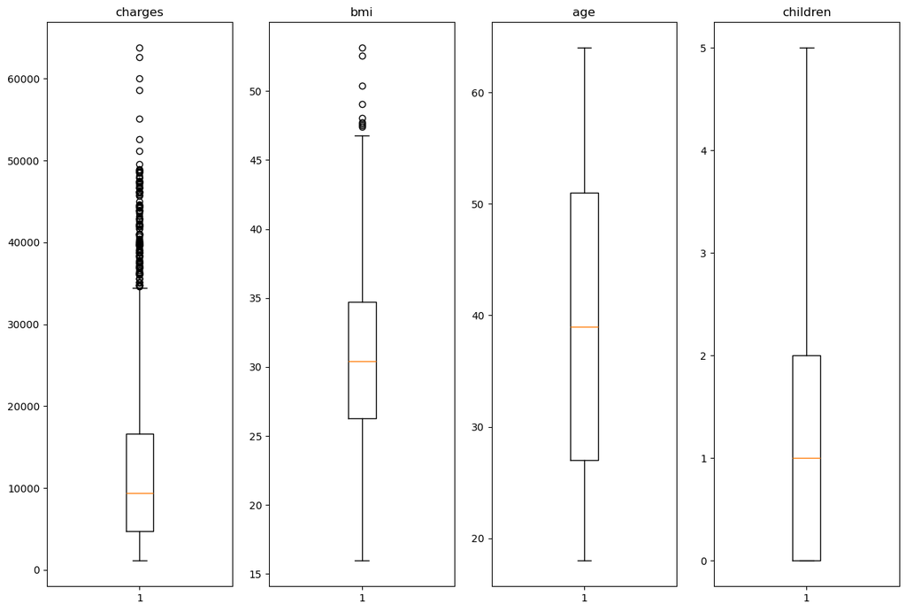

```python
fig, ax = plt.subplots(1,4, figsize = (15, 10))
ax[0].title.set_text('charges')
ax[0].boxplot(df['charges'])
ax[1].title.set_text('bmi')
ax[1].boxplot(df['bmi'])
ax[2].title.set_text('age')
ax[2].boxplot(df['age'])
ax[3].title.set_text('children')
ax[3].boxplot(df['children'])
```

Задание 6 Используя признак charges или imb, проверить, выполняется ли центральная предельная теорема. Использовать различные длины выборок n. Количество выборок = 300. Вывести результат в виде гистограмм. Найти стандартное отклонение и среднее для полученных распределений. Сделать выводы.

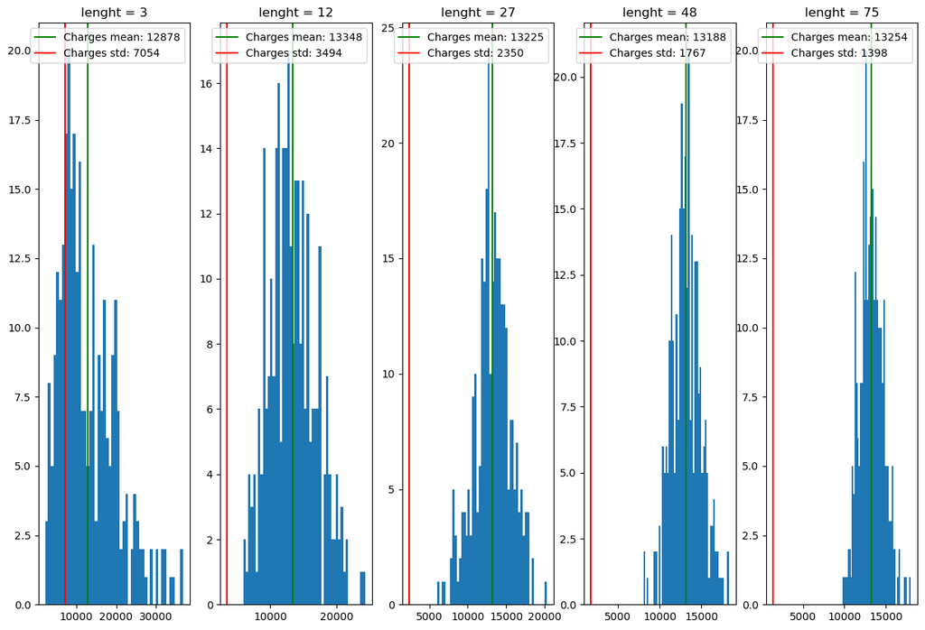

```python
fig, ax = plt.subplots(1,5, figsize = (15, 10))
for i in range(5):
    tmp = np.random.choice(df['charges'].to_numpy(), [3*(i+1)**2, 300])
    tmp = np.mean(tmp, axis = 0)
    ax[i].hist(tmp, bins = 50)
    ax[i].title.set_text('lenght = ' + str(3*(i+1)**2))
    mean = np.mean(tmp)
    ax[i].axvline(x = mean, color = 'g', linestyle = '-', label=f'Charges mean: {mean:.0f}')
    std = tmp.std()
    ax[i].axvline(x = std, color = 'r', linestyle = '-', label=f'Charges std: {std:.0f}')
    ax[i].legend()
```

Вывод: чем больше количество элементов в выборке, тем меньше стандартное отклонение, тем больше видно, что разброс от медианы влево, вправо уменьшается и стремится к 3 стандартным отклонениям.

Задание 7 Построить 95% и 99% доверительный интервал для среднего значения расходов и среднего значения индекса массы тела.

```python
dataC = df['charges'].to_numpy()
Ch1 = sts.norm.interval(confidence=0.95, loc=np.mean(dataC), scale=sts.sem(dataC))
Ch2 = sts.norm.interval(confidence=0.99, loc=np.mean(dataC), scale=sts.sem(dataC))
dataB = df['bmi'].to_numpy()
B1 = sts.norm.interval(confidence=0.95, loc=np.mean(dataB), scale=sts.sem(dataB))
B2 = sts.norm.interval(confidence=0.99, loc=np.mean(dataB), scale=sts.sem(dataB))
print("Доверительный интервал 95% для ср. расходов", Ch1)
print("Доверительный интервал 99% для ср. расходов", Ch2)
print("Доверительный интервал 95% для ср. индекса массы тела", B1)
print("Доверительный интервал 99% для ср. индекса массы тела", B2)
```

```
Доверительный интервал 95% для ср. расходов (12621.54197822916, 13919.302552053354)
Доверительный интервал 99% для ср. расходов (12417.649014863586, 14123.195515418927)
Доверительный интервал 95% для ср. индекса массы тела (30.336642971534822, 30.990150750438275)
Доверительный интервал 99% для ср. индекса массы тела (30.233969458168303, 31.092824263804793)
```

Задание 8 Проверить распределения следующих признаков на нормальность: индекс массы тела, расходы. Сформулировать нулевую и альтернативную гипотезы. Для каждого признака использовать KS-тест и q-q plot. Сделать выводы на основе полученных p-значений.

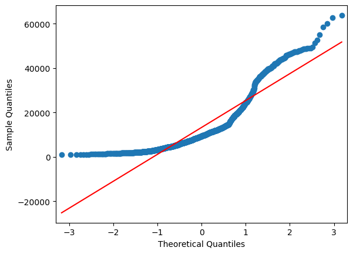

```
KstestResult(statistic=0.18846450965981876, pvalue=4.381949677777384e-42, statistic_location=0.016551407834487126, statistic_sign=1)
```

```python
import statsmodels.api as sm
import pylab as py
sm.qqplot(df['charges'], line='s')
py.show()

standarted_df = (df['charges']-df['charges'].mean ())/df['charges'].std()
sts.kstest(standarted_df, 'norm')
```

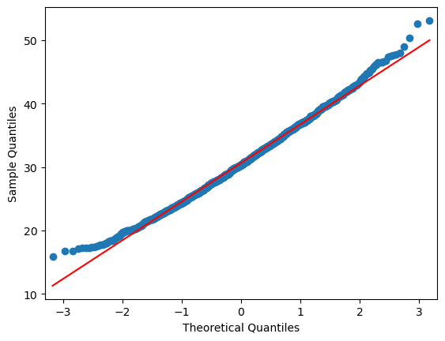

```
KstestResult(statistic=0.026099881197044816, pvalue=0.31627982428380297, statistic_location=-0.2768686636601763, statistic_sign=1)
```

```python
sm.qqplot(df['bmi'], line='s')
py.show()

standarted_df = (df['bmi']-df['bmi'].mean ())/df['bmi'].std()
sts.kstest(standarted_df, 'norm')
```

Вывод: для расходов p-значение намного меньше 0.05, что значит, что нулевая гипотеза, о том, что распределение близко к нормальному отвергается. Для индекса массы тела p-значение намного больше 0.05, что говорит о том, что нулевая гипотеза о близости распределения к нормальному верна.

Задание 9 Загрузить данные из файла “ECDCCases.csv”.

```python
df1 = pd.read_csv(r'C:\Users\hanst\Downloads\ECDCCases.csv')
df1
```

|  | dateRep | day | month | year | cases | deaths | countriesAndTerritories | geoId | countryterritoryCode | popData2019 | continentExp | Cumulative_number_for_14_days_of_COVID-19_cases_per_100000 |
| --- | --- | --- | --- | --- | --- | --- | --- | --- | --- | --- | --- | --- |
| 0 | 14/12/2020 | 14 | 12 | 2020 | 746 | 6 | Afghanistan | AF | AFG | 38041757.0 | Asia | 9.013779 |
| 1 | 13/12/2020 | 13 | 12 | 2020 | 298 | 9 | Afghanistan | AF | AFG | 38041757.0 | Asia | 7.052776 |
| 2 | 12/12/2020 | 12 | 12 | 2020 | 113 | 11 | Afghanistan | AF | AFG | 38041757.0 | Asia | 6.868768 |
| 3 | 12/12/2020 | 12 | 12 | 2020 | 113 | 11 | Afghanistan | AF | AFG | 38041757.0 | Asia | 6.868768 |
| 4 | 11/12/2020 | 11 | 12 | 2020 | 63 | 10 | Afghanistan | AF | AFG | 38041757.0 | Asia | 7.134266 |
| ... | ... | ... | ... | ... | ... | ... | ... | ... | ... | ... | ... | ... |
| 61899 | 25/03/2020 | 25 | 3 | 2020 | 0 | 0 | Zimbabwe | ZW | ZWE | 14645473.0 | Africa | NaN |
| 61900 | 24/03/2020 | 24 | 3 | 2020 | 0 | 1 | Zimbabwe | ZW | ZWE | 14645473.0 | Africa | NaN |
| 61901 | 23/03/2020 | 23 | 3 | 2020 | 0 | 0 | Zimbabwe | ZW | ZWE | 14645473.0 | Africa | NaN |
| 61902 | 22/03/2020 | 22 | 3 | 2020 | 1 | 0 | Zimbabwe | ZW | ZWE | 14645473.0 | Africa | NaN |
| 61903 | 21/03/2020 | 21 | 3 | 2020 | 1 | 0 | Zimbabwe | ZW | ZWE | 14645473.0 | Africa | NaN |

61904 rows × 12 columns

Задание 10 Проверить в данных наличие пропущенных значений. Вывести количество пропущенных значений в процентах. Удалить два признака, в которых больше всех пропущенных значений. Для оставшихся признаков обработать пропуски: для категориального признака использовать заполнение значением по умолчанию (например, «other»), для числового признака использовать заполнение медианным значением. Показать, что пропусков больше в данных нет.

```python
print(df1.isnull().values.any())
df1.isnull().sum()/df1.shape[0] * 100
```

```
True
```

```
dateRep                                                       0.000000
day                                                           0.000000
month                                                         0.000000
year                                                          0.000000
cases                                                         0.000000
deaths                                                        0.000000
countriesAndTerritories                                       0.000000
geoId                                                         0.444236
countryterritoryCode                                          0.198695
popData2019                                                   0.198695
continentExp                                                  0.000000
Cumulative_number_for_14_days_of_COVID-19_cases_per_100000    4.650750
dtype: float64
```

```python
df1 = df1.drop(columns=['Cumulative_number_for_14_days_of_COVID-19_cases_per_100000', 'geoId'])
df1.countryterritoryCode = df1.countryterritoryCode.fillna('other')
df1.popData2019 = df1.popData2019.fillna(df1['popData2019'].median())
print(df1.isnull().values.any())
df1.isnull().sum()/df1.shape[0] * 100
```

```
False
```

```
dateRep                    0.0
day                        0.0
month                      0.0
year                       0.0
cases                      0.0
deaths                     0.0
countriesAndTerritories    0.0
countryterritoryCode       0.0
popData2019                0.0
continentExp               0.0
dtype: float64
```

Задание 11 Посмотреть статистику по данным, используя describe(). Сделать выводы о том, какие признаки содержат выбросы. Посмотреть, для каких стран количество смертей в день превысило 3000 и сколько таких дней было.

```python
df1.describe()
```

|  | day | month | year | cases | deaths | popData2019 |
| --- | --- | --- | --- | --- | --- | --- |
| count | 61904.000000 | 61904.000000 | 61904.000000 | 61904.000000 | 61904.000000 | 6.190400e+04 |
| mean | 15.629232 | 7.067104 | 2019.998918 | 1155.079026 | 26.053987 | 4.091909e+07 |
| std | 8.841624 | 2.954816 | 0.032881 | 6779.010824 | 131.222948 | 1.529798e+08 |
| min | 1.000000 | 1.000000 | 2019.000000 | -8261.000000 | -1918.000000 | 8.150000e+02 |
| 25% | 8.000000 | 5.000000 | 2020.000000 | 0.000000 | 0.000000 | 1.324820e+06 |
| 50% | 15.000000 | 7.000000 | 2020.000000 | 15.000000 | 0.000000 | 7.169456e+06 |
| 75% | 23.000000 | 10.000000 | 2020.000000 | 273.000000 | 4.000000 | 2.851583e+07 |
| max | 31.000000 | 12.000000 | 2020.000000 | 234633.000000 | 4928.000000 | 1.433784e+09 |

[output not shown]

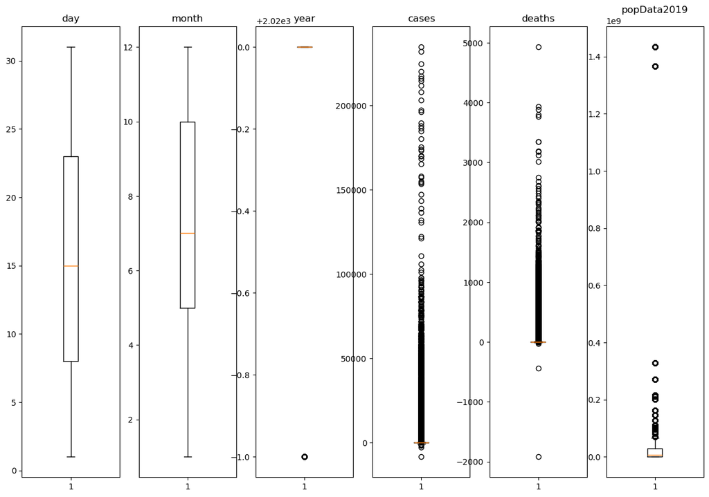

```python
fig, ax = plt.subplots(1,6, figsize = (15, 10))
ax[0].title.set_text('day')
ax[0].boxplot(df1['day'])
ax[1].title.set_text('month')
ax[1].boxplot(df1['month'])
ax[2].title.set_text('year')
ax[2].boxplot(df1['year'])
ax[3].title.set_text('cases')
ax[3].boxplot(df1['cases'])
ax[4].title.set_text('deaths')
ax[4].boxplot(df1['deaths'])
ax[5].title.set_text('popData2019')
ax[5].boxplot(df1['popData2019'])
```

```python
df1[df1['deaths'] > 3000]
```

|  | dateRep | day | month | year | cases | deaths | countriesAndTerritories | countryterritoryCode | popData2019 | continentExp |
| --- | --- | --- | --- | --- | --- | --- | --- | --- | --- | --- |
| 2118 | 02/10/2020 | 2 | 10 | 2020 | 14001 | 3351 | Argentina | ARG | 44780675.0 | America |
| 16908 | 07/09/2020 | 7 | 9 | 2020 | -8261 | 3800 | Ecuador | ECU | 17373657.0 | America |
| 37038 | 09/10/2020 | 9 | 10 | 2020 | 4936 | 3013 | Mexico | MEX | 127575529.0 | America |
| 44888 | 14/08/2020 | 14 | 8 | 2020 | 9441 | 3935 | Peru | PER | 32510462.0 | America |
| 44909 | 24/07/2020 | 24 | 7 | 2020 | 4546 | 3887 | Peru | PER | 32510462.0 | America |
| 59007 | 12/12/2020 | 12 | 12 | 2020 | 234633 | 3343 | United_States_of_America | USA | 329064917.0 | America |
| 59009 | 10/12/2020 | 10 | 12 | 2020 | 220025 | 3124 | United_States_of_America | USA | 329064917.0 | America |
| 59016 | 03/12/2020 | 3 | 12 | 2020 | 203311 | 3190 | United_States_of_America | USA | 329064917.0 | America |
| 59239 | 24/04/2020 | 24 | 4 | 2020 | 26543 | 3179 | United_States_of_America | USA | 329064917.0 | America |
| 59245 | 18/04/2020 | 18 | 4 | 2020 | 30833 | 3770 | United_States_of_America | USA | 329064917.0 | America |
| 59247 | 16/04/2020 | 16 | 4 | 2020 | 30148 | 4928 | United_States_of_America | USA | 329064917.0 | America |

```python
df1[df1['deaths'] > 3000].shape[0]
```

```
11
```

```python
Задание 12
Найти дублирование данных. Удалить дубликаты.
```

```python
df1.duplicated().any()
df1 = df1.drop_duplicates()
```

Задание 13 Загрузить данные из файла “bmi.csv”. Взять оттуда две выборки. Одна выборка – это индекс массы тела людей c региона northwest, вторая выборка – это индекс массы тела людей с региона southwest. Сравнить средние значения этих выборок, используя t-критерий Стьюдента. Предварительно проверить выборки на нормальность (критерий ШопироУилка) и на гомогенность дисперсии (критерий Бартлетта).

```python
df2 = pd.read_csv(r'C:\Users\hanst\Downloads\bmi.csv')
df2
```

|  | bmi | region |
| --- | --- | --- |
| 0 | 22.705 | northwest |
| 1 | 28.880 | northwest |
| 2 | 27.740 | northwest |
| 3 | 25.840 | northwest |
| 4 | 28.025 | northwest |
| ... | ... | ... |
| 645 | 20.600 | southwest |
| 646 | 38.600 | southwest |
| 647 | 33.400 | southwest |
| 648 | 44.700 | southwest |
| 649 | 25.800 | southwest |

650 rows × 2 columns

```python
nw = df2[df2['region'] == 'northwest']['bmi']
sw = df2[df2['region'] == 'southwest']['bmi']
print(sts.shapiro(nw), sts.shapiro(sw)) #p-value выше 0.05, следовательно, выборки имеют нормальное распределение
```

```
ShapiroResult(statistic=0.995464981663833, pvalue=0.4655897798883668) ShapiroResult(statistic=0.9949269360950754, pvalue=0.36296471144790743)
```

```python
print(sts.bartlett(nw, sw)) #p-value превышает 0.05, следовательно, дисперсии выборок примерно одинаковы
```

```
BartlettResult(statistic=3.4000745256459286, pvalue=0.06519347353581818)
```

```python
print(sts.ttest_ind(nw, sw))
#p-значение ниже 0.05, следовательно нулевая гипотеза отвергается, выборки принадлежат к разным генеральным совокупностям и их средние значения различны
```

```
TtestResult(statistic=-3.2844171500398582, pvalue=0.001076958496307695, df=648.0)
```

Задание 14 Кубик бросили 600 раз, получили следующие результаты: N Количество выпадений 1 – 97, 2 – 98, 3 – 109, 4 – 95, 5 – 97, 6 – 104. С помощью критерия Хи-квадрат проверить, является ли полученное распределение равномерным. Использовать функцию scipy.stats.chisquare().

```python
cube = pd.DataFrame({'real': [97, 98, 109, 95, 97, 104], 'expected': [100, 100, 100, 100, 100, 100]})
sts.chisquare(cube['real'], cube['expected'])
```

```
Power_divergenceResult(statistic=1.44, pvalue=0.9198882077437889)
```

Задание 15 С помощью критерия Хи-квадрат проверить, являются ли переменные зависимыми. Создать датафрейм, используя представленный код. Использовать функцию scipy.stats.chi2_contingency().

```python
data = pd.DataFrame({'Женат': [89,17,11,43,22,1],
 'Гражданский брак': [80,22,20,35,6,4],
 'Не состоит в отношениях': [35,44,35,6,8,22]})
data.index = ['Полный рабочий день','Частичная занятость','Временно не работает','На домохозяйстве','На пенсии','Учёба']
data
```

|  | Женат | Гражданский брак | Не состоит в отношениях |
| --- | --- | --- | --- |
| Полный рабочий день | 89 | 80 | 35 |
| Частичная занятость | 17 | 22 | 44 |
| Временно не работает | 11 | 20 | 35 |
| На домохозяйстве | 43 | 35 | 6 |
| На пенсии | 22 | 6 | 8 |
| Учёба | 1 | 4 | 22 |

```python
sts.chi2_contingency(data)
```

```
Chi2ContingencyResult(statistic=122.29654948595365, pvalue=1.7291616900960234e-21, dof=10, expected_freq=array([[74.664, 68.136, 61.2  ],
       [30.378, 27.722, 24.9  ],
       [24.156, 22.044, 19.8  ],
       [30.744, 28.056, 25.2  ],
       [13.176, 12.024, 10.8  ],
       [ 9.882,  9.018,  8.1  ]]))
```

Влияет ли семейное положение на занятость?

Ответ: да, семейное положение влияет на занятость: p-значение меньше 0,05, следовательно, переменные зависимы.